# Homework 9-1 Decision Trees

#### Use a classification tree to predict spam.

Predictors: 48 word percentages of occurence in emails 6 character percentages CAP- uninterrupted capital letter sequence

Predicted class: spam: 0=“email”, 1=“spam”

Q10 (5pts): Read the file “spambase.csv” and assign it to a variable called “spam.df”. Convert the “spam” column to a factor with levels “email”, “spam”. Using the seed value given below, create a training data set that contains 66% of the rows by random sampling, and a test set containing the rest of the data. Also create a variable “true.labels” and assign to it the rows from the test set for the “Purchase” column.

```r
set.seed(12345)
spam.df <- read.csv("spambase.csv")
spam.vec<-factor(spam.df$spam, labels= c("email", "spam"))
spam.df$spam <- spam.vec
data.size<-nrow(spam.df)
train.size<-0.66
train.row.nums<-sample(1:data.size, data.size*train.size, replace=FALSE)
train1.data<-subset(spam.df[train.row.nums,])
test.row.nums<-setdiff(1:data.size,train.row.nums)
test1.data<-subset(spam.df[test.row.nums,])
true1.labels<-test1.data$spam
```

Q11 (5pts): Fit a classification tree to the training data with “spam” as the predicted class. Print a summary of the fitted model. What is the training error rate? How many leaf nodes does the tree have? How many predictors are used?

```r
spam.tree<- tree(spam ~., train1.data)
summary(spam.tree)
```

```
##
## Classification tree:
## tree(formula = spam ~ ., data = train1.data)
## Variables actually used in tree construction:
##  [1] "char_freq_..4"              "word_freq_remove"
##  [3] "char_freq_..3"              "word_freq_hp"
##  [5] "capital_run_length_longest" "word_freq_our"
##  [7] "word_freq_free"             "capital_run_length_average"
##  [9] "word_freq_george"           "word_freq_edu"
## Number of terminal nodes:  13
## Residual mean deviance:  0.4716 = 1426 / 3023
## Misclassification error rate: 0.07806 = 237 / 3036
```

| # The training error rate is 0.07806. There are 13 leaf nodes and 10 predictors used. |
| --- |

Q12 (5pts): Create a plot of the tree including the selection criteria and terminal node labels. Also print text representation of the tree to the console. Pick a node that predicts “email”. Write the rules that lead to this node starting at the root. How many data points are included in this node. How many of these data are classified as “spam”?

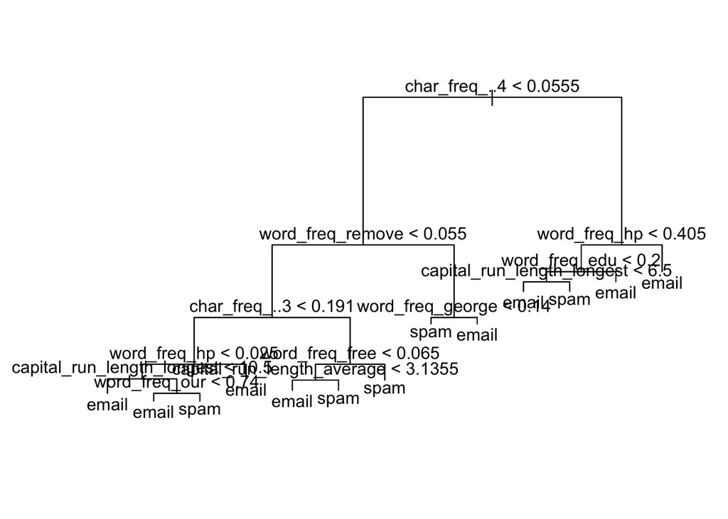

```r
plot(spam.tree)
text(spam.tree, pretty=0)
```

Q13 (5pts): Create predictions on the test set, print a confusion matrix of the results as well as the misclassification rate.

```r
tree1.pred<- predict(spam.tree, test1.data, type="class")
table(tree1.pred, true1.labels)
```

```
##           true1.labels
## tree1.pred email spam
##      email   887   88
##      spam     52  538
```

```r
num2.incorrect.labels<- sum(tree1.pred!=true1.labels)
misc.rate2 <- num2.incorrect.labels/(nrow(test1.data))
misc.rate2
```

```
## [1] 0.08945687
```

Q14 (5pts): Use the cv.tree function on the tree fitted to the training set to determine the best tree size. Plot the tree size on the horizontal axis and the cv error on the vertical axis.

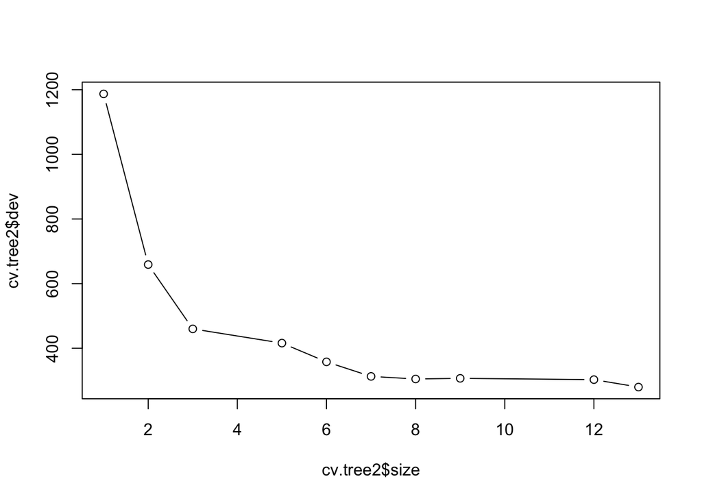

```r
cv.tree2<-cv.tree(spam.tree, FUN=prune.misclass)
plot(cv.tree2$size, cv.tree2$dev, type="b")
```

Q15 (5pts): Create a pruned tree of size 6. Plot the pruned tree with labels.

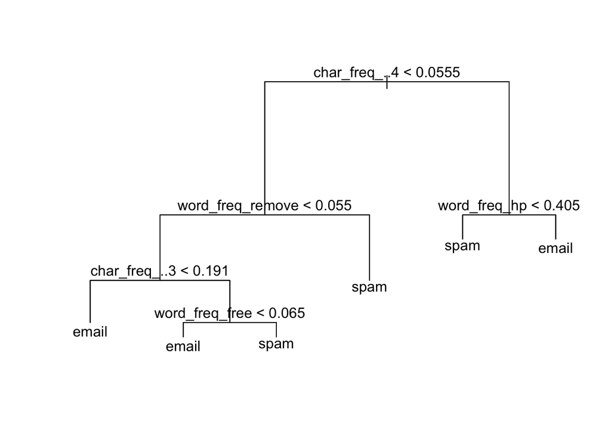

```r
pruned2.tree<-prune.misclass(spam.tree, best=6)
plot(pruned2.tree)
text(pruned2.tree, pretty=0)
```

Q16 (10pts): Display the fit error rates for both the unpruned and prined trees. Which has a better fit? Explain why you would or would not expect this result.

```r
summary(spam.tree)
```

```
##
## Classification tree:
## tree(formula = spam ~ ., data = train1.data)
## Variables actually used in tree construction:
##  [1] "char_freq_..4"              "word_freq_remove"
##  [3] "char_freq_..3"              "word_freq_hp"
##  [5] "capital_run_length_longest" "word_freq_our"
##  [7] "word_freq_free"             "capital_run_length_average"
##  [9] "word_freq_george"           "word_freq_edu"
## Number of terminal nodes:  13
## Residual mean deviance:  0.4716 = 1426 / 3023
## Misclassification error rate: 0.07806 = 237 / 3036
```

```r
summary(pruned2.tree)
```

```
##
## Classification tree:
## snip.tree(tree = spam.tree, nodes = c(8L, 5L, 6L, 18L))
## Variables actually used in tree construction:
## [1] "char_freq_..4"    "word_freq_remove" "char_freq_..3"
## [4] "word_freq_free"   "word_freq_hp"
## Number of terminal nodes:  6
## Residual mean deviance:  0.6369 = 1930 / 3030
## Misclassification error rate: 0.1057 = 321 / 3036
```

[output not shown]

Q17 (10pts): Create predictions and a confusion matrix for the pruned tree. Calculate themisclassification rate for the prined tree. Compare the misclassification rate for the unpruned and pruned trees. Explain why you would or would not expect this result.

```r
prune2.tree.pred<- predict(pruned2.tree, test1.data, type="class")
table(prune2.tree.pred, true1.labels)
```

```
##                 true1.labels
## prune2.tree.pred email spam
##            email   888  122
##            spam     51  504
```

```r
num3.incorrect.labels<- sum(prune2.tree.pred!=true1.labels)
misc3.rate <- num3.incorrect.labels/(nrow(test1.data))
misc3.rate
```

```
## [1] 0.1105431
```

[output not shown]